# Modelling and Explaining Electricity Prices in Europe

Analysis of France & Germany Spot Markets (QRT Challenge)

Sammy RABHINE

2026-05-22

# 1 Introduction

How can we explain the daily variations in electricity futures prices in France and Germany using meteorological, energy, and cross-border exchange factors?

# 2 Data Processing

Displaying the first 5 rows of the dataset

```r
# Data loading
X_train <- read_csv("X_train.csv")
y_train <- read_csv("y_train.csv")
X_test  <- read_csv("X_test_final.csv")

### Data Overview and Structure
# Display first 5 rows
X_train %>%
  head(5) %>%
  kable(caption = "Overview of the first 5 rows of the training dataset") %>%
  kable_styling(bootstrap_options = c("striped", "hover", "condensed"), full_width = F) %>%
  scroll_box(width = "100%")
```

Overview of the first 5 rows of the training dataset

| ID | DAY_ID | COUNTRY | DE_CONSUMPTION | FR_CONSUMPTION | DE_FR_EXCHANGE | FR_DE_EXCHANGE | DE_NET_EXPORT | FR_NET_EXPORT | DE_NET_IMPORT | FR_NET_IMPORT | DE_GAS | FR_GAS | DE_COAL | FR_COAL | DE_HYDRO | FR_HYDRO | DE_NUCLEAR | FR_NUCLEAR | DE_SOLAR | FR_SOLAR | DE_WINDPOW | FR_WINDPOW | DE_LIGNITE | DE_RESIDUAL_LOAD | FR_RESIDUAL_LOAD | DE_RAIN | FR_RAIN | DE_WIND | FR_WIND | … |
| --- | --- | --- | --- | --- | --- | --- | --- | --- | --- | --- | --- | --- | --- | --- | --- | --- | --- | --- | --- | --- | --- | --- | --- | --- | --- | --- | --- | --- | --- | --- |
| 1054 | 206 | FR | 0.2100987 | -0.4274582 | -0.6065235 | 0.6065235 | NA | 0.6928596 | NA | -0.6928596 | 0.4412383 | -0.2137659 | 0.7406271 | 0.2887816 | 2.2090471 | 0.2078382 | 0.7096141 | -0.1904635 | 0.1017661 | 1.2489112 | -0.5733701 | -0.2694605 | 0.8703443 | 0.6266664 | -0.4446609 | -0.1726797 | -0.5563555 | -0.7908234 | -0.2831604 | … |
| 2049 | 501 | FR | -0.0223993 | -1.0034525 | -0.0220632 | 0.0220632 | -0.5735195 | -1.1308376 | 0.5735195 | 1.1308376 | 0.1747728 | 0.4269397 | -0.1703917 | -0.7621528 | 0.1879639 | -0.8071117 | -1.8827402 | -2.1859608 | 1.9874280 | 3.2373804 | -0.0355144 | -0.1073498 | -0.1943079 | -0.3954691 | -1.1831938 | -1.2402996 | -0.7704573 | 1.5223309 | 0.8284119 | … |
| 1924 | 687 | FR | 1.3950351 | 1.9786654 | 1.0213052 | -1.0213052 | -0.6220212 | -1.6825866 | 0.6220212 | 1.6825866 | 2.3519135 | 2.1222413 | 1.5722666 | 0.7770530 | -0.1085783 | 0.7791423 | -1.8971086 | 0.7351374 | -1.1155833 | -0.3710387 | -0.2987546 | -0.1412391 | 0.4282725 | 1.3366246 | 1.9472728 | -0.4807004 | -0.3133378 | 0.4311345 | 0.4876076 | … |
| 297 | 720 | DE | -0.9833239 | -0.8491980 | -0.8395859 | 0.8395859 | -0.2708698 | 0.5632299 | 0.2708698 | -0.5632299 | 0.4878182 | 0.1946590 | -1.4738167 | -0.7860250 | -0.3684172 | 1.3204835 | -0.2055467 | -1.5895539 | 1.7515229 | 0.5629444 | -0.0100901 | 0.3668851 | -2.3305572 | -1.1918888 | -0.9769740 | -1.1148379 | -0.5075702 | -0.4994094 | -0.2362487 | … |
| 1101 | 818 | FR | 0.1438074 | -0.6170377 | -0.9249900 | 0.9249900 | NA | 0.9903236 | NA | -0.9903236 | 0.2386930 | -0.2408619 | 1.0037343 | -0.2749747 | -0.2301795 | -0.7959830 | -0.0055806 | 0.1769346 | 0.6935427 | 0.7235874 | -0.7749409 | -0.5644977 | 0.6910404 | 0.5716129 | -0.5262671 | -0.5414654 | -0.4245497 | -1.0881583 | -1.0115597 | … |

```r
# Variable type verification
type_info <- data.frame(
  Variable = names(X_train),
  Type = sapply(X_train, class)
)

type_info %>%
  count(Type) %>%
  kable(caption = "Distribution of variable types") %>%
  kable_styling(full_width = F, position = "left")
```

Distribution of variable types

| Type | n |
| --- | --- |
| character | 1 |
| numeric | 34 |

I then wanted to see which variables had missing values.

## 2.1 Missing Value Analysis

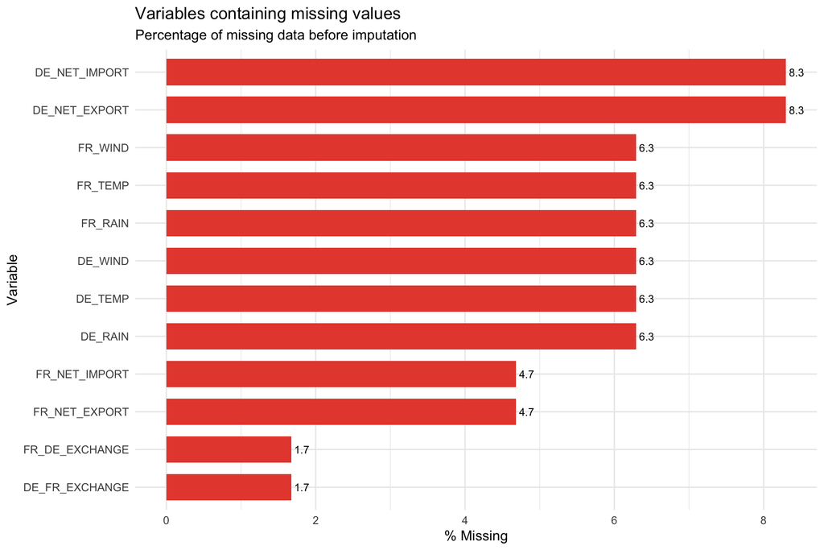

```r
### Missing Value Analysis
# X_train
na_summary <- X_train %>%
  summarise(across(everything(), ~sum(is.na(.)))) %>%
  pivot_longer(everything(), names_to = "Variable", values_to = "Nb_NA") %>%
  mutate(Percentage = (Nb_NA / nrow(X_train)) * 100) %>%
  filter(Nb_NA > 0) %>%
  arrange(desc(Percentage))

# Missing data visualisation
ggplot(na_summary, aes(x = reorder(Variable, Percentage), y = Percentage)) +
  geom_bar(stat = "identity", fill = "#e74c3c", width = 0.7) +
  coord_flip() +
  theme_minimal() +
  labs(
    title = "Variables containing missing values",
    subtitle = "Percentage of missing data before imputation",
    x = "Variable",
    y = "% Missing"
  ) +
  geom_text(aes(label = round(Percentage, 1)), hjust = -0.2, size = 3)
```

I then decided to proceed with imputation of the missing values.

```r
# 1. Variable group definitions
meteo_vars <- c("FR_WINDPOW", "DE_WINDPOW", "FR_TEMP", "DE_TEMP", "FR_RAIN", "DE_RAIN")

exchange_vars <- c("FR_DE_EXCHANGE", "DE_FR_EXCHANGE")

net_vars <- c("FR_NET_IMPORT", "FR_NET_EXPORT", "DE_NET_IMPORT", "DE_NET_EXPORT")

# 2. WEATHER imputation (Linear interpolation)
X_train <- X_train %>%
  mutate(across(
    any_of(meteo_vars),
    ~ na.approx(.x, na.rm = FALSE)
  ))

# 3. EXCHANGE imputation (Linear interpolation)
X_train <- X_train %>%
  mutate(across(
    any_of(exchange_vars),
    ~ na.approx(.x, na.rm = FALSE)
  ))

# 4. NET FLOWS imputation (Interpolation with cap of 3 + Rolling Mean)
X_train <- X_train %>%
  # Step A: Interpolation for small gaps (maxgap = 3)
  mutate(across(
    any_of(net_vars),
    ~ na.approx(.x, na.rm = FALSE, maxgap = 3)
  )) %>%
  # Step B: Rolling mean for remaining gaps
  mutate(across(
    any_of(net_vars),
    ~ ifelse(
      is.na(.x),
      rollapply(.x, width = 7, FUN = mean, fill = NA, align = "center", partial = TRUE),
      .x
    )
  ))

# 5. Edge cleaning (Last Observation Carried Forward / Backward)
vars_to_clean <- c(meteo_vars, exchange_vars, net_vars)

X_train <- X_train %>%
  mutate(across(
    any_of(vars_to_clean),
    ~ na.locf(.x, na.rm = FALSE)
  )) %>%
  mutate(across(
    any_of(vars_to_clean),
    ~ na.locf(.x, fromLast = TRUE, na.rm = FALSE)
  ))

# Final check
print("Remaining missing values:")
```

```
## [1] "Remaining missing values:"
```

```r
print(colSums(is.na(X_train %>% select(any_of(vars_to_clean)))))
```

```
##     FR_WINDPOW     DE_WINDPOW        FR_TEMP        DE_TEMP        FR_RAIN
##              0              0              0              0              0
##        DE_RAIN FR_DE_EXCHANGE DE_FR_EXCHANGE  FR_NET_IMPORT  FR_NET_EXPORT
##              0              0              0              0              0
##  DE_NET_IMPORT  DE_NET_EXPORT
##              0              0
```

```r
# Merge X_train and y_train
df_train <- X_train %>%
  left_join(y_train, by = "ID")
```

After performing the variable imputation, I wanted to see how the variables were distributed (features + target).